# Assignment 1: MATH 4753

## 11-Process Voltage Readings

### a.

```r
volt=read.csv("Oldlocationtable.csv", header=TRUE)
volt
```

```
##    Class    Class.Interval Data.Tabulation Frequency Relative.Frequency
## 1      1   8.0000 - 8.2889               |         1               0.03
## 2      2   8.2889 - 8.5778                         0               0.00
## 3      3   8.5778 - 8.8667             |||         3               0.10
## 4      4   8.8667 - 9.1556                         0               0.00
## 5      5   9.1556 - 9.4445                         0               0.00
## 6      6   9.4445 - 9.7334            ||||         4               0.17
## 7      7  9.7334 - 10.0223  ||||| ||||| ||        12               0.40
## 8      8 10.0223 - 10.3112      ||||| ||||         9               0.30
## 9      9 10.3112 - 10.6001               |         1               0.03
## 10    NA                                          NA                 NA
## 11    NA                                          NA                 NA
```

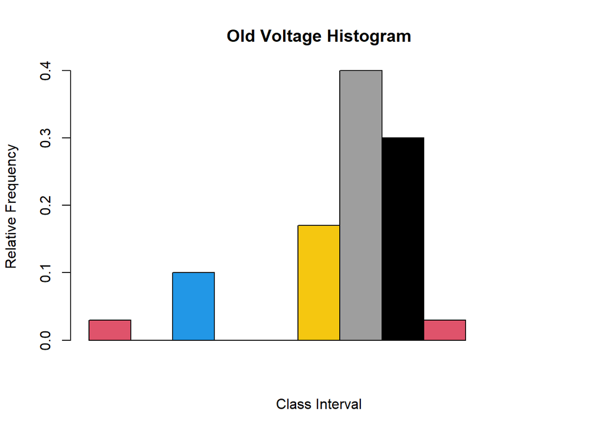

```r
barplot(volt$Relative.Frequency, space = 0, xlab = "Class Interval", ylab = "Relative Frequency", main = "Old Voltage Histogram", col = 2:11)
```

### b.

```r
voltage = read.csv("VOLTAGE.csv", header = TRUE)
head(voltage)
```

```
##   VOLTAGE LOCATION
## 1    9.98      OLD
## 2   10.26      OLD
## 3   10.05      OLD
## 4   10.29      OLD
## 5   10.03      OLD
## 6    8.05      OLD
```

```r
oldv = voltage[voltage$LOCATION == "OLD",]$VOLTAGE
stem(oldv)
```

```
##
##   The decimal point is at the |
##
##    8 | 1
##    8 | 778
##    9 |
##    9 | 677888899
##   10 | 0000000011122333
##   10 | 6
```

The stem-and-leaf display is more informative about where most of the voltage readings lie as it clearly shows the cluster from 9.6-10.3

### c.

```r
voltage.df = data.frame(voltage)
new<-subset(voltage.df,subset=LOCATION=="NEW")
new$VOLTAGE->vtn
vtn
```

```
##  [1]  9.19  9.63 10.10  9.70 10.09  9.60 10.05 10.12  9.49  9.37 10.01  8.82
## [13]  9.43 10.03  9.85  9.27  8.83  9.39  9.48  9.64  8.82  8.65  8.51  9.14
## [25]  9.75  8.78  9.35  9.54  9.36  8.68
```

```r
max(vtn)
```

```
## [1] 10.12
```

```r
min(vtn)
```

```
## [1] 8.51
```

```r
lept<-min(vtn)-0.05
rept<-max(vtn)+0.05
rnge<-rept-lept
inc<-rnge/9
inc
```

```
## [1] 0.19
```

```r
seq(lept, rept,by=inc)->cl
cl
```

```
##  [1]  8.46  8.65  8.84  9.03  9.22  9.41  9.60  9.79  9.98 10.17
```

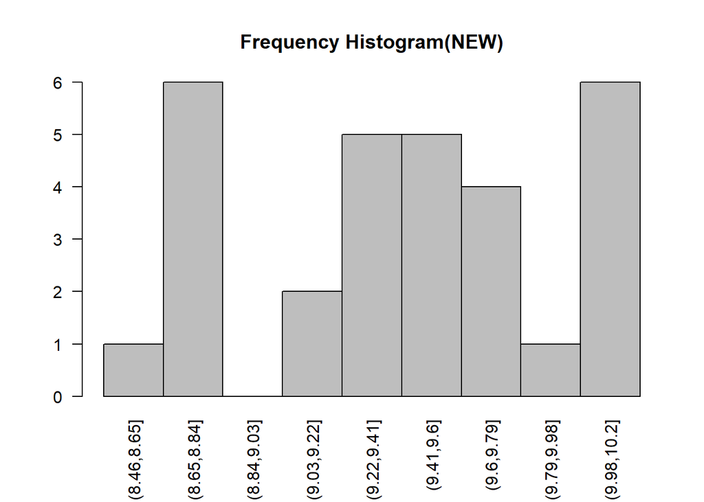

```r
cvtn<-cut(vtn,breaks=cl)
new.tab=table(cvtn)
barplot(new.tab,space=0,main="Frequency Histogram(NEW)",las=2)
```

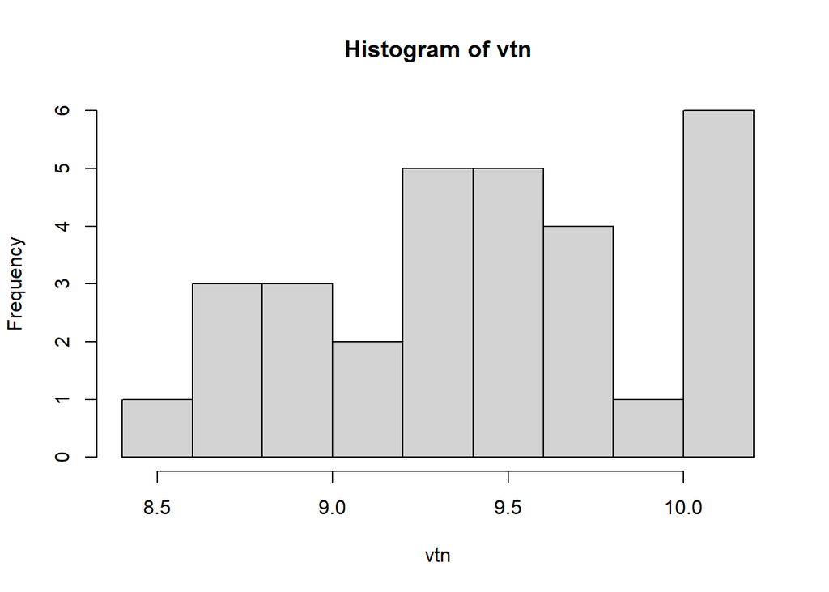

```r
hist(vtn,nclass=10)
```

### d.

It appears that the manufacturing process cannot be established locally, the new process is not as good as the old process, as there are more readings below 9.2 volts.

### e.

```r
mean(oldv)
```

```
## [1] 9.803667
```

```r
median(oldv)
```

```
## [1] 9.975
```

```r
mode(oldv)
```

```
## [1] "numeric"
```

```r
mean(vtn)
```

```
## [1] 9.422333
```

```r
median(vtn)
```

```
## [1] 9.455
```

```r
mode(vtn)
```

```
## [1] "numeric"
```

The mean of the old voltage dataset is 9.8037. The median of the old voltage dataset is 9.975. The mode is not meaningful in this situation. The mean of the new voltage dataset is 9.4223. The median of the new voltage dataset is 9.455. The mode is not meaninful in this situation.

## 12-Surface Roughness of Pipe

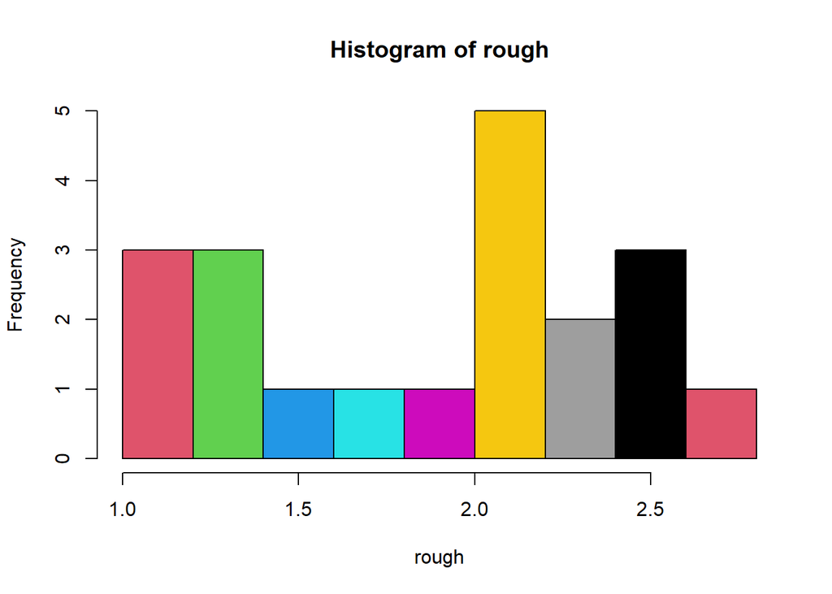

```r
rp=read.csv("ROUGHPIPE.csv", header=TRUE)
rough=rp$ROUGH
hist(rough, col = 2:12)
```

```r
mean(rough)
```

```
## [1] 1.881
```

```r
sd(rough) * 2
```

```
## [1] 1.047823
```

The interval from 0.8332 to 2.9288 micrometers will likely contain 95% of all coated pipe roughness measurements by the empirical rule.

## 13-Mongolian Desert Ants

### a.

```r
ga=read.csv("GOBIANTS.csv", header=TRUE)
head(ga)
```

```
##   Site      Region Rain Temp PlantCov AntSpecies Diversity
## 1    1  Dry Steppe  196  5.7       40          3      0.89
## 2    2  Dry Steppe  196  5.7       52          3      0.83
## 3    3  Dry Steppe  179  7.0       40         52      1.31
## 4    4  Dry Steppe  197  8.0       43          7      1.48
## 5    5  Dry Steppe  149  8.5       27          5      0.97
## 6    6 Gobi Desert  112 10.7       30         49      0.46
```

```r
as = ga$AntSpecies
mean(as)
```

```
## [1] 12.81818
```

```r
median(as)
```

```
## [1] 5
```

```r
mode(as)
```

```
## [1] "numeric"
```

The mean is 12.8182 The median is 5 The modes are 4 and 5

### b.

I would recommend using the median as the measure of central tendency to describe the center of the number of ant species distribution because the mean is skewed by two outliers, having 49 and 52 ant species respectively. The mode is also useful, but because there are two modes, and one of the modes is the median, I think the median does a better job at representing the central tendency.

### c.

```r
dstpc=ga[ga$Region=="Dry Steppe",]$PlantCov
mean(dstpc)
```

```
## [1] 40.4
```

```r
median(dstpc)
```

```
## [1] 40
```

```r
mode(dstpc)
```

```
## [1] "numeric"
```

The mean is 40.4% The median is 40% The mode is 40%

### d.

```r
gdtpc=ga[ga$Region=="Gobi Desert",]$PlantCov
mean(gdtpc)
```

```
## [1] 28
```

```r
median(gdtpc)
```

```
## [1] 26
```

```r
mode(gdtpc)
```

```
## [1] "numeric"
```

The mean is 28% The median is 26% The mode is 30%

### e.

Yes, the center of total plant cover percentage distribution appears to be different at the two regions. In the dry steppe region, the center of total plant cover percentage distribution is around 40% while it’s around 26-30% in the gobi desert region.

## 14-Speed of Light from Galaxies

### a.

```r
library(lattice)
g2 = read.csv("GALAXY2.csv", header = TRUE)
head(g2)
```

```
##   VELOCITY
## 1    22922
## 2    20210
## 3    21911
## 4    19225
## 5    18792
## 6    21993
```

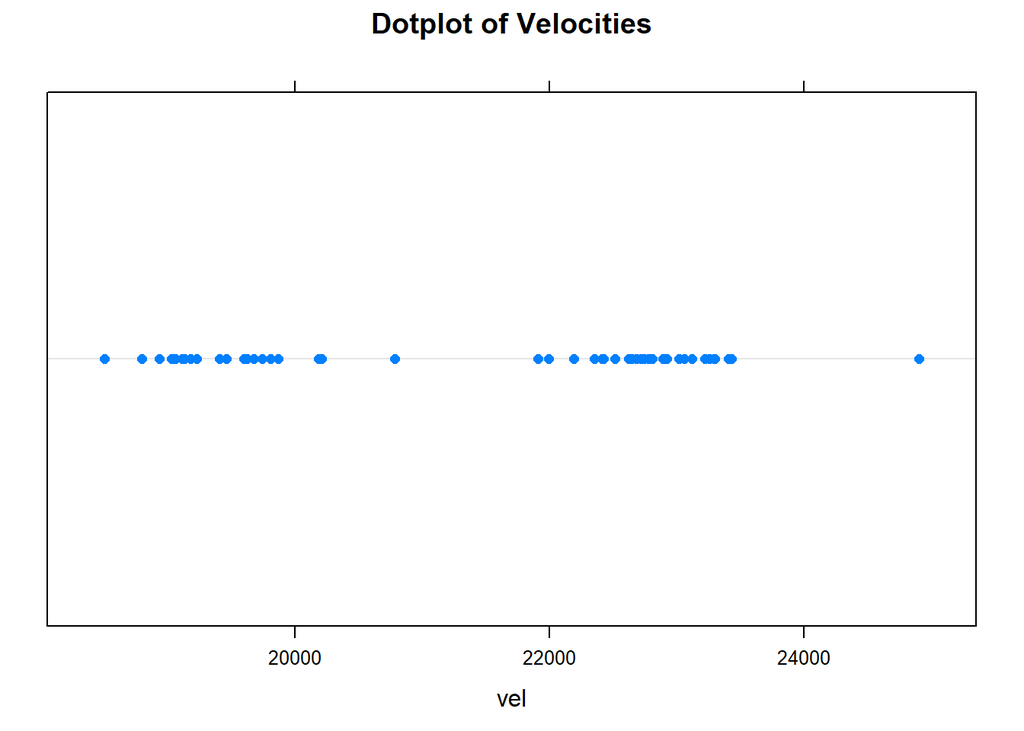

```r
vel=g2$VELOCITY
dotplot(vel, main = "Dotplot of Velocities")
```

### b.

Yes, there is evidence to support the double cluster theory. In the dotplot above, there are two distinct groupings of velocities, one centered around roughly 19500 km/s and the other centered roughly around 22500 km/s.

### c.

```r
A1775A = g2[g2$VELOCITY < 21000,]
A1775B = g2[g2$VELOCITY > 21000,]
mean(A1775A)
```

```
## [1] 19462.24
```

```r
sd(A1775A)
```

```
## [1] 532.2868
```

```r
mean(A1775B)
```

```
## [1] 22838.47
```

```r
sd(A1775B)
```

```
## [1] 560.9767
```

The mean velocity for galaxy cluster A1775A is 19462.24 km/s and the standard deviation is 532.2868 km/s. The mean velocity for galaxy cluster A1775B is 22838.47 km/s and the standard deviation is 560.9767 km/s.

### d.

A galaxy of velocity 20,000 km/s is likely to belong to cluster A1775A because this velocity falls within roughly one standard deviation of the mean galaxy velocity for cluster A1775A.

## 15-ggplot

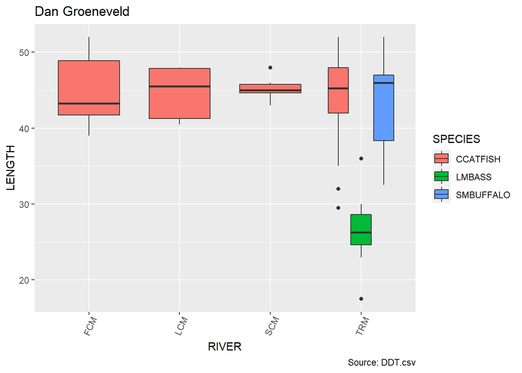

```r
library(ggplot2)
ddt = read.csv("DDT.csv", header = TRUE)

 b = ggplot(ddt, aes(x = RIVER, y = LENGTH))
 b = b + geom_boxplot(aes(fill= SPECIES)) +
  theme(axis.text.x = element_text(angle=65, vjust=0.6)) +
  labs(title="Dan Groeneveld",
       caption="Source: DDT.csv",
       x="RIVER",
       y="LENGTH")
b
```